# Clinical utility of pre-extubation respiratory sampling

TIM POP study — Final statistical analysis

Author

Alexandre Sitbon

# Executive summary

This analysis is based on the **final locked TIM POP database**, comprising **122 patients with postoperative pneumonia (POP)**, all of whom underwent pre-extubation respiratory sampling.

**NoteKey findings**

- **Pre-extubation microbiological yield:** 81/122 (**66.4%**)
- **Broad microbiological concordance:** 54/81 (**66.7%**)
- **Specific concordance excluding oropharyngeal flora:** 33/81 (**40.7%**)
- **Specific concordance in the overall cohort:** 33/122 (**27.0%**)
- **Inadequate empirical antimicrobial therapy:** 22/100 (**22.0%**)
- **Potentially actionable prior microbiology:** 8/122 (**6.6%**)
- **Resistance and empirical inadequacy:** OR **10.02** (95% CI 3.13–36.66; P <0.001)

Pre-extubation respiratory microbiology frequently identified microorganisms and showed subsequent organism-specific concordance in a substantial subset of patients. However, prior organism-specific information coincided with subsequent inadequate empirical antimicrobial therapy in only a minority of the overall cohort.

Potential actionability should be interpreted as an **upper-bound estimate**, because the precise time at which microbiological identification and antimicrobial susceptibility results became available to clinicians is unknown.

# Main results

## Study population and microbiological yield

The FINAL analytical cohort comprised **122 patients** with postoperative pneumonia.

Pre-extubation respiratory sampling was performed in **122/122 (100.0%)** patients.

Among these samples:

- **81 were positive**;
- **41 were negative**.

The microbiological yield was therefore **81/122 (66.4%; 95% CI 57.3–74.7%)**.

## Microbiological concordance

At least one microorganism recovered before extubation was subsequently recovered at POP diagnosis in **54/81 (66.7%; 95% CI 55.3–76.8%)** positive pre-extubation samples.

Because non-specific oropharyngeal flora may artificially inflate apparent microbiological overlap, the principal organism-specific analysis excluded oropharyngeal flora from both pre-extubation and POP samples.

After this exclusion, specific organism-level concordance was observed in **33/81 (40.7%; 95% CI 29.9–52.2%)** positive pre-extubation samples.

This corresponded to **33/122 (27.0%) of the overall cohort**.

## Microbiological trajectories

Beyond the overall concordance rate, we examined individual microbiological trajectories between positive pre-extubation respiratory samples and subsequent POP microbiology.

The Sankey plot illustrates the relationship between microorganisms identified before extubation and those subsequently recovered at POP diagnosis. Flows are classified according to whether at least one **specific microorganism**, excluding non-specific oropharyngeal flora, was recovered at both time points.

[figure not shown]

Figure 1: Figure 2. Microbiological trajectories between positive pre-extubation respiratory sampling and postoperative pneumonia. Each flow represents a microorganism trajectory between pre-extubation and POP microbiology. Green flows indicate patient-level specific microbiological concordance after exclusion of oropharyngeal flora; red flows indicate absence of specific concordance.

Among the **81 patients with positive pre-extubation microbiology**, at least one microorganism was subsequently recovered at POP diagnosis in **54 (66.7%)** patients.

After exclusion of non-specific oropharyngeal flora, specific organism-level concordance remained in **33/81 (40.7%)** patients.

The Sankey representation nevertheless demonstrates substantial microbiological turnover between the two sampling periods: a positive pre-extubation respiratory sample did not necessarily identify the specific microorganism subsequently recovered at POP diagnosis.

Importantly, microbiological concordance alone does not establish clinical utility. The subsequent analysis therefore evaluates whether concordant pre-extubation information could potentially have altered empirical antimicrobial selection.

## Potential clinical actionability

The clinically relevant subgroup was defined by the combination of:

1. positive pre-extubation respiratory microbiology;
2. specific organism-level concordance with subsequent POP;
3. inadequate empirical antimicrobial therapy at POP diagnosis.

Among the **33 patients with specific microbiological concordance**, **8 subsequently received inadequate empirical antimicrobial therapy**.

Thus, prior organism-specific microbiological information was potentially relevant to empirical antimicrobial selection in **8/122 (6.6%; 95% CI 2.9–12.5%)** of the overall cohort.

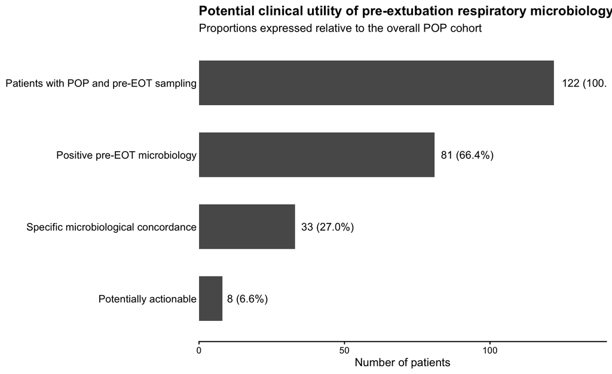

Figure 2: Figure 1. Clinical utility cascade of pre-extubation respiratory microbiology. Specific concordance excludes non-specific oropharyngeal flora. Potential actionability corresponds to specific concordance associated with subsequent inadequate empirical antimicrobial therapy.

**WarningInterpretation**

The **8/122** estimate represents **potential rather than demonstrated clinical actionability**.

The FINAL database establishes the date of pre-extubation sampling but does not establish the precise time at which microorganism identification and antimicrobial susceptibility results became available to clinicians.

## Empirical antimicrobial adequacy

Empirical antimicrobial adequacy could be assessed in **100/122 patients**.

Empirical therapy was:

- adequate in **78/100 (78.0%)**;
- inadequate in **22/100 (22.0%)**.

Empirical antimicrobial adequacy according to pre-extubation microbiological positivity.

| Pre-EOT microbiology | n | Inadequate therapy |
| --- | --- | --- |
| Negative | 25 | 6/25 (24.0%) |
| Positive | 75 | 16/75 (21.3%) |

This comparison is descriptive because pre-extubation microbiological positivity may reflect differences in patient characteristics and respiratory microbial ecology.

## Antimicrobial resistance and empirical treatment inadequacy

Resistance phenotype information was interpretable in **110 patients**, of whom **32 (29.1%)** had at least one reported antimicrobial resistance phenotype.

Empirical antimicrobial inadequacy was substantially more frequent in patients with a reported antimicrobial resistance phenotype.

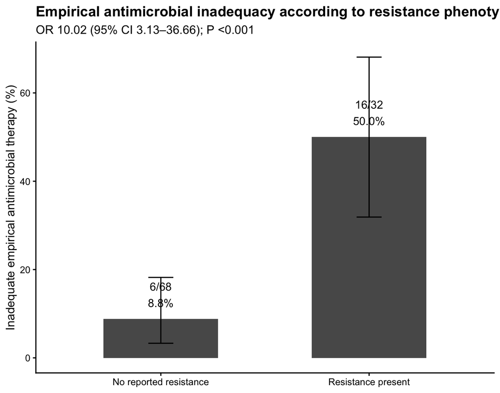

Figure 3: Figure 3. Empirical antimicrobial inadequacy according to the presence of a reported antimicrobial resistance phenotype. Error bars represent exact 95% confidence intervals.

The unadjusted association between reported antimicrobial resistance and empirical antimicrobial inadequacy corresponded to an OR of **10.02** (95% CI **3.13–36.66**; P **<0.001**).

This association is exploratory and should not be interpreted as evidence of an independent causal effect.

## Main numerical results

Table 1: Table 1. Main microbiological findings and potential clinical utility.

| Characteristic | n/N (%) |
| --- | --- |
| Pre-extubation respiratory sampling | 122/122 (100.0%) |
| Positive pre-extubation microbiology | 81/122 (66.4%) |
| Negative pre-extubation microbiology | 41/122 (33.6%) |
| Any microbiological concordance among positive samples | 54/81 (66.7%) |
| Specific concordance excluding oropharyngeal flora | 33/81 (40.7%) |
| Specific concordance in overall cohort | 33/122 (27.0%) |
| Potentially actionable in overall cohort | 8/122 (6.6%) |

# Secondary analyses

## Potentially actionable cases

Eight patients combined specific pre-extubation/POP microbiological concordance with subsequent inadequate empirical antimicrobial therapy.

**NoteWhy these cases matter**

These patients define the maximum subgroup in which prior organism-specific microbiological information might theoretically have influenced empirical antimicrobial selection.

They do **not** demonstrate that prior microbiological information was available or acted upon when empirical therapy was prescribed.

Individual cases with potentially actionable pre-extubation microbiological information.

| Numero | date_prelevement_preeot | date_diagnostic_ppo | Pre-EOT 1 | Pre-EOT 2 | Pre-EOT 3 | POP 1 | POP 2 | POP 3 | resistance_code | adaptation_48h |
| --- | --- | --- | --- | --- | --- | --- | --- | --- | --- | --- |
| 8 | 2024-07-31 | 2024-08-01 | Enterococcus faecium | No microorganism | No microorganism | Enterococcus faecium | No microorganism | No microorganism | 3 | 1 |
| 18 | 2024-05-24 | 2024-05-25 | Pseudomonas aeruginosa | No microorganism | No microorganism | Pseudomonas aeruginosa | No microorganism | No microorganism | 5 | 1 |
| 32 | 2021-08-11 | 2021-08-15 | Hafnia alvei | No microorganism | No microorganism | Hafnia alvei | No microorganism | No microorganism | 4 | 1 |
| 54 | 2024-09-22 | 2024-09-26 | Enterococcus faecium | No microorganism | No microorganism | Enterococcus faecium | No microorganism | No microorganism | 0 | 1 |
| 64 | 2024-03-28 | 2024-04-02 | Oropharyngeal flora | Enterobacter aerogenes | No microorganism | Oropharyngeal flora | Enterobacter aerogenes | No microorganism | 4 | 1 |
| 76 | 2024-09-16 | 2024-09-19 | Pseudomonas aeruginosa | No microorganism | No microorganism | Pseudomonas aeruginosa | No microorganism | No microorganism | 5 | 1 |
| 78 | 2025-02-07 | 2025-02-11 | Oropharyngeal flora | Enterococcus faecium | No microorganism | Enterococcus faecium | Serratia marcescens | No microorganism | 2 | 1 |
| 110 | 2025-04-01 | 2025-04-03 | Escherichia coli | No microorganism | No microorganism | Escherichia coli | No microorganism | No microorganism | 1 | 1 |

## Timing of potentially actionable information

The interval between pre-extubation sampling and POP diagnosis provides temporal context for potential clinical utility.

Timing between pre-extubation respiratory sampling and POP diagnosis in potentially actionable cases.

| Patient | Pre-EOT sampling | POP diagnosis | Interval (days) |
| --- | --- | --- | --- |
| 8 | 2024-07-31 | 2024-08-01 | 1 |
| 18 | 2024-05-24 | 2024-05-25 | 1 |
| 32 | 2021-08-11 | 2021-08-15 | 4 |
| 54 | 2024-09-22 | 2024-09-26 | 4 |
| 64 | 2024-03-28 | 2024-04-02 | 5 |
| 76 | 2024-09-16 | 2024-09-19 | 3 |
| 78 | 2025-02-07 | 2025-02-11 | 4 |
| 110 | 2025-04-01 | 2025-04-03 | 2 |

The median interval between pre-extubation sampling and POP diagnosis in these cases was **3.5 days** [IQR **1.8–4.0**].

The interval between sampling and POP diagnosis does **not establish the exact time at which microorganism identification and antimicrobial susceptibility results became available to clinicians**.

## Antimicrobial adaptation at 48 hours

Antimicrobial adaptation at 48 hours was evaluable in **100 patients** and occurred in **63 (63.0%)**.

### According to pre-extubation microbiological positivity

| Pre-EOT microbiology | n | Adaptation at 48 h |
| --- | --- | --- |
| Negative | 25 | 13/25 (52.0%) |
| Positive | 75 | 50/75 (66.7%) |

Global Fisher exact test: **P = 0.234**.

### According to specific microbiological concordance

| Specific concordance | n | Adaptation at 48 h |
| --- | --- | --- |
| No | 44 | 28/44 (63.6%) |
| Yes | 31 | 22/31 (71.0%) |

These analyses are exploratory.

## Clinical outcomes according to empirical antimicrobial adequacy

Clinical outcomes according to empirical antimicrobial adequacy.

| Empirical therapy | n | ICU LOS, median [IQR] | Hospital LOS, median [IQR] | ICU deaths | Hospital deaths | POP recurrence |
| --- | --- | --- | --- | --- | --- | --- |
| Adequate | 78 | 16.5 [11.0–31.0] | 40.0 [21.0–66.0] | 13 | 15 | 29 |
| Inadequate | 22 | 20.5 [12.0–39.8] | 63.5 [24.5–101.5] | 1 | 2 | 7 |

Exploratory univariable comparisons of clinical outcomes.

| Outcome | P value |
| --- | --- |
| ICU length of stay | 0.364 |
| Hospital length of stay | 0.114 |
| ICU mortality | 0.294 |
| Hospital mortality | 0.348 |
| POP recurrence | 0.802 |

These outcome analyses are secondary and exploratory.

# Supplementary analyses

## Supplementary Figure S1 — Pre-extubation microbiology

The distribution of microorganisms isolated before extubation is shown below.

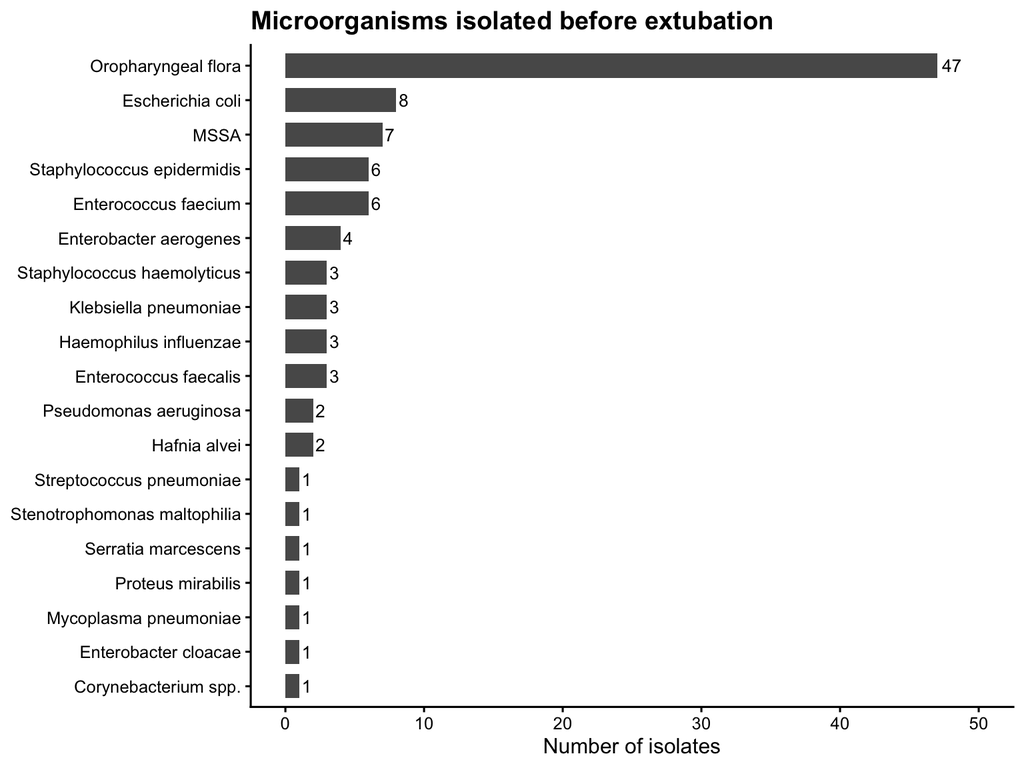

Figure 4: Supplementary Figure S1. Distribution of microorganisms isolated from pre-extubation respiratory samples.

## Supplementary Figure S2 — POP microbiology

The distribution of microorganisms isolated at POP diagnosis is shown below.

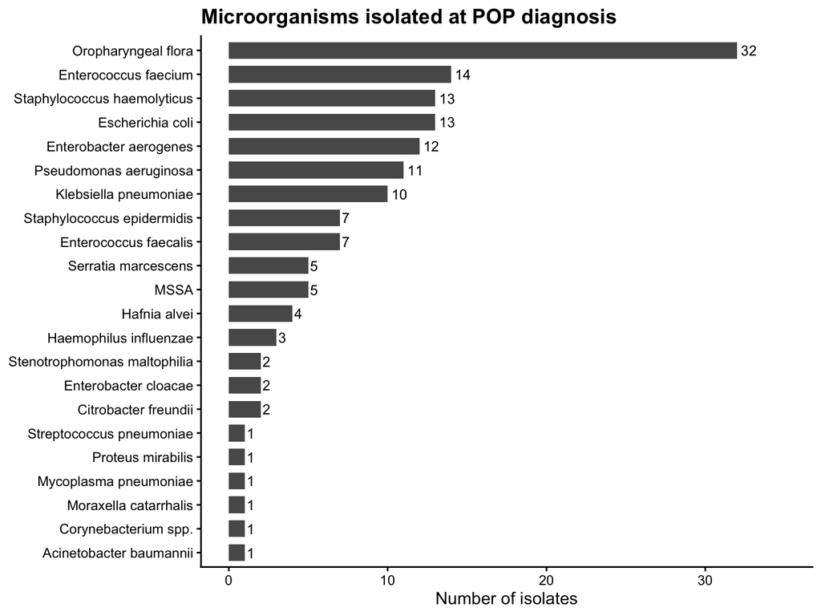

Figure 5: Supplementary Figure S2. Distribution of microorganisms isolated at postoperative pneumonia diagnosis.

## Resistance phenotypes

Distribution of reported antimicrobial resistance phenotypes.

| Resistance phenotype | n | Percent |
| --- | --- | --- |
| No reported resistance | 78 | 70.9 |
| Methicillin resistance | 10 | 9.1 |
| Cephalosporinase | 9 | 8.2 |
| ESBL | 7 | 6.4 |
| Highly resistant Pseudomonas | 4 | 3.6 |
| Carbapenemase | 2 | 1.8 |

# Technical audit

**NoteReproducibility and internal validation**

This section documents database integrity, coding decisions and internal consistency checks.

It is retained for reproducibility and audit purposes and is **not part of the primary clinical interpretation**.

## Database integrity

Patient-level database integrity.

| Parameter | Value |
| --- | --- |
| Number of observations | 122 |
| Number of variables | 117 |
| Unique patient identifiers | 122 |
| Duplicated patient identifiers | 0 |

## Coding decisions

### Pre-extubation sampling

According to the FINAL dictionary:

- **0** = no respiratory sample;
- **1** = protected distal sampling;
- **2** = tracheal aspirate;
- **3** = sputum sample;
- **4** = bronchoalveolar lavage.

Absence of sampling is therefore defined by **code 0**, rather than missingness.

Distribution of pre-extubation sampling codes.

| Sampling code | n |
| --- | --- |
| 1 | 55 |
| 2 | 18 |
| 4 | 49 |

### Binary variables

Some FINAL database cells contain the text value `"Autre"` in otherwise binary variables.

These values were **not recoded as either 0 or 1** and were treated as unavailable for the corresponding analysis.

**Show analysis code**

```r
stopifnot(
  all(
    na.omit(
      unique(data$adequacy)
    ) %in% c(0, 1)
  )
)

stopifnot(
  all(
    na.omit(
      unique(data$initial_failure)
    ) %in% c(0, 1)
  )
)

stopifnot(
  all(
    na.omit(
      unique(data$adaptation_48h)
    ) %in% c(0, 1)
  )
)
```

### Microbiological coding

The FINAL microbiological dictionary contains microorganism codes **0–22**.

Microorganism coding used in the FINAL database.

| Code | Microorganism |
| --- | --- |
| 0 | No microorganism |
| 1 | MSSA |
| 2 | Oropharyngeal flora |
| 3 | Enterococcus faecium |
| 4 | Citrobacter freundii |
| 5 | Hafnia alvei |
| 6 | Klebsiella pneumoniae |
| 7 | Escherichia coli |
| 8 | Pseudomonas aeruginosa |
| 9 | Proteus mirabilis |
| 10 | Corynebacterium spp. |
| 11 | Serratia marcescens |
| 12 | Enterobacter aerogenes |
| 13 | Enterococcus faecalis |
| 14 | Haemophilus influenzae |
| 15 | Acinetobacter baumannii |
| 16 | Staphylococcus epidermidis |
| 17 | Moraxella catarrhalis |
| 18 | Staphylococcus haemolyticus |
| 19 | Mycoplasma pneumoniae |
| 20 | Enterobacter cloacae |
| 21 | Stenotrophomonas maltophilia |
| 22 | Streptococcus pneumoniae |

### Antimicrobial resistance coding

According to the FINAL dictionary:

- **0** = no reported resistance;
- **1** = ESBL;
- **2** = carbapenemase-producing Enterobacterales;
- **3** = methicillin resistance;
- **4** = cephalosporinase;
- **5** = highly resistant *Pseudomonas* phenotype.

Codes 1–5 were grouped as **any reported antimicrobial resistance** for the binary resistance analysis.

## Core analytical definitions

### Positive pre-extubation microbiology

A pre-extubation respiratory sample was considered positive when at least one microorganism code **>0** was recorded in one of the three microorganism fields.

### Broad microbiological concordance

Broad concordance was defined as recovery at POP diagnosis of at least one microorganism also recovered before extubation.

### Specific microbiological concordance

Specific concordance applied the same definition after exclusion of **oropharyngeal flora (code 2)** from both pre-extubation and POP microbiology.

### Potential actionability

Potential actionability required:

1. positive pre-extubation microbiology;
2. specific organism-level concordance;
3. subsequent inadequate empirical antimicrobial therapy.

This definition represents an **upper-bound estimate** and does not establish that the prior microbiological result was available to or used by the treating clinician.

## Raw coding audit

The following output is retained only for internal verification of the principal database variables.

**Show analysis code**

```r
lapply(
  data[key_variables],
  function(x)
    table(
      x,
      useNA = "ifany"
    )
)
```

```
$type_prelevement_preeot
x
 1  2  4
55 18 49

$pathogene_preeot
x
 0  1  2  3  5  6  7  8 10 11 12 13 14 16 19 21 22
41  7 44  2  2  3  4  2  1  1  3  1  2  6  1  1  1

$pathogene_preeot_2
x
  0   2   3   7   9  12  13  14  18  20
104   3   4   3   1   1   1   1   3   1

$pathogene_preeot_3
x
  0   7  13
120   1   1

$adequation_antibiotherapie_probabiliste
x
    0     1 Autre  <NA>
   22    78     3    19

$echec_traitement_initial
x
    0     1 Autre  <NA>
   78    22     1    21

$adaptation_ATB_48h
x
    0     1 Autre  <NA>
   37    63     1    21

$resistance_phenotypique_germe
x
    0     1     2     3     4     5 Autre  <NA>
   78     7     2    10     9     4     3     9
```

## Internal consistency checks

The following checks deliberately stop rendering if the core analytical cascade becomes internally inconsistent.

**Show analysis code**

```r
stopifnot(
  n_total == 122
)

stopifnot(
  n_performed ==
    n_positive + n_negative
)

stopifnot(
  n_specific_concordant <=
    n_concordant
)

stopifnot(
  n_concordant <=
    n_positive
)

stopifnot(
  n_specific_actionable <=
    n_specific_concordant
)

stopifnot(
  n_adequate +
    n_inadequate ==
    n_adequacy_available
)
```

Final internal consistency audit.

| Metric | n |
| --- | --- |
| Total cohort | 122 |
| Pre-EOT sampled | 122 |
| Pre-EOT positive | 81 |
| Pre-EOT negative | 41 |
| Broad concordance | 54 |
| Specific concordance | 33 |
| Adequacy evaluable | 100 |
| Adequate empirical therapy | 78 |
| Inadequate empirical therapy | 22 |
| Potentially actionable | 8 |

# Final interpretation

The FINAL database comprised **122 patients with postoperative pneumonia**, all of whom underwent pre-extubation respiratory sampling.

Pre-extubation microbiology was positive in **81/122 (66.4%)** patients.

At least one microorganism recovered before extubation was subsequently recovered at POP diagnosis in **54/81 (66.7%)** positive samples.

After exclusion of non-specific oropharyngeal flora, specific organism-level concordance was observed in **33/81 (40.7%)**, corresponding to **27.0% of the overall cohort**.

Empirical antimicrobial adequacy was evaluable in **100 patients** and was inadequate in **22 (22.0%)**.

Among patients with specific microbiological concordance, **8 received inadequate empirical antimicrobial therapy**. Thus, prior organism-specific microbiological information was potentially relevant to empirical antimicrobial selection in **8/122 (6.6%; 95% CI 2.9–12.5%)** of the overall cohort.

This proportion should be interpreted as an **upper-bound estimate of potential actionability**, because the FINAL database establishes the date of pre-extubation sampling but does not establish the precise time at which microorganism identification and antimicrobial susceptibility results became available to the treating clinician.

Reported antimicrobial resistance was strongly associated with empirical antimicrobial inadequacy in unadjusted analysis (OR **10.02**, 95% CI **3.13–36.66**, P **<0.001**).

Overall, the FINAL data indicate that pre-extubation respiratory microbiology frequently identified microorganisms and showed subsequent microbiological overlap in a substantial subset of patients. However, organism-specific information coincided with subsequent inadequate empirical antimicrobial therapy in only a minority of the overall cohort. The clinical value of routine pre-extubation sampling therefore depends not only on microbiological concordance but also on the timely availability and actual use of prior microbiological and susceptibility information.